# Proyecto1

Christian Cabrera

14/6/2021

## Proyecto 01 Visuaización y análisis de datos climáticos

### Datos climáticos de LIberia 2015-2019

### Se cargan los paquetes

```r
library(dplyr)
library(ggplot2)
library(hrbrthemes)
library(grid)
library(gridExtra)
```

#### Se carga el archivo csv con el que se va a trabajar y se fija el directorio para tener los datos disponibles todo el tiempo

```r
datos <- read.csv("liberia_datos_climaticos.csv", na.strings = "", sep = ",", dec = ",")
```

### Ahora bien, con el comando head y dim se van ver los datos generales de el archivo

```r
head(datos)
```

```
##       Date Temperatura..Celsius. HumedadRelativa.... VelocidadViento..m.s.
## 1 1/1/2015                 27.88               65.08                  7.08
## 2 2/1/2015                 28.06               66.21                  6.47
## 3 3/1/2015                 28.91               65.21                  5.40
## 4 4/1/2015                 28.13               67.88                  6.61
## 5 5/1/2015                 28.00               66.25                  8.85
## 6 6/1/2015                 27.68               68.00                  7.40
##   Lluvia..mm. Irradiacion..W.m2. EvapoTranspiracion..mm.
## 1           0             228.58                    5.04
## 2           0             231.17                    4.86
## 3           0             244.17                    5.12
## 4           0             182.38                    4.13
## 5           0             246.00                    5.38
## 6           0             189.46                    4.23
```

```r
dim(datos)
```

```
## [1] 1551    7
```

### El siguiente comando mediante permite indagar mejor dentro del archivo csv ya que este posee NA

```r
datos[!complete.cases(datos),]
```

```
##           Date Temperatura..Celsius. HumedadRelativa.... VelocidadViento..m.s.
## 1106 10/1/2018                 25.88               73.79                    NA
## 1107 11/1/2018                 25.30               79.79                    NA
## 1108 12/1/2018                 26.71               75.96                    NA
## 1146 19/2/2018                 28.14               59.67                    NA
## 1147 20/2/2018                 27.55               61.50                    NA
## 1164  9/3/2018                 28.51               62.29                    NA
## 1165 10/3/2018                 29.20               62.08                    NA
## 1166 11/3/2018                 28.60               64.00                    NA
## 1167 12/3/2018                 27.96               67.67                    NA
## 1168 13/3/2018                 28.51               65.13                    NA
## 1169 14/3/2018                 29.34               60.67                    NA
## 1170 15/3/2018                 28.98               58.96                    NA
## 1171 16/3/2018                 29.02               56.67                    NA
## 1193  7/4/2018                    NA                  NA                    NA
```

[output cut: 37 more lines]

### Se limpia el archivo de NA

```r
datos <- na.omit(datos)
```

### Para un mejor manejo de la informacion y del trabajo se van a nombrar los encabezados de las columnas

```r
names(datos) <- c("Fecha","Temperatura", "Humedad", "Vel.Viento", "Lluvia", "Irradiacion", "EvapoTranspiracion")
```

### A continuacion, se generaran los histogramas de cada columna.

```r
hist1 <- ggplot(datos, aes(x = Temperatura)) +
  geom_histogram(binwidth = 0.2,
                 col = 'black',
                 fill = 'orange') +
  ggtitle('Temperatura') +
  xlab('Grados Celcius') +
  ylab('Frecuencia') +
  theme_ipsum()

hist2 <- ggplot(datos, aes(x = Humedad)) +
  geom_histogram(binwidth = 2,
                 col = 'black',
                 fill = 'blue') +
  ggtitle('Humedad relativa') +
  xlab('% de humedad relativa') +
  ylab('Frecuencia') +
  theme_ipsum()

hist3 <- ggplot(datos, aes(x = Vel.Viento)) +
  geom_histogram(binwidth = 1,
                 col = 'black',
                 fill = 'gray') +
  ggtitle('Velocidad del viento') +
  xlab('Velocidad en m/s') +
  ylab('Frecuencia') +
  theme_ipsum()

hist4 <- ggplot(datos, aes(x = Lluvia)) +
  geom_histogram(binwidth = 5,
                 col = 'black',
                 fill = '#339999') +
  ggtitle('Cantidad de lluvia') +
  xlab('Cant. de lluvia en mm') +
  ylab('Frecuencia') +
  theme_ipsum()

hist5 <- ggplot(datos, aes(x = Irradiacion)) +
  geom_histogram(binwidth = 7,
                 col = 'black',
                 fill = 'yellow') +
  ggtitle('Niveles de irradiacion') +
  xlab('Irradiacion en W/m2') +
  ylab('Frecuencia') +
  theme_ipsum()

hist6 <- ggplot(datos, aes(x = EvapoTranspiracion)) +
  geom_histogram(binwidth = 1,
                 col = 'black',
                 fill = 'green') +
  ggtitle('Cantidad de EvapoTranspiracion') +
  xlab('Cant. de EvapoTranspiracion en mm') +
  ylab('Frecuencia') +
  theme_ipsum()
```

### Una vez graficados los histogramas uno a uno se unifican en un solo grafico con el comando grind.arrange

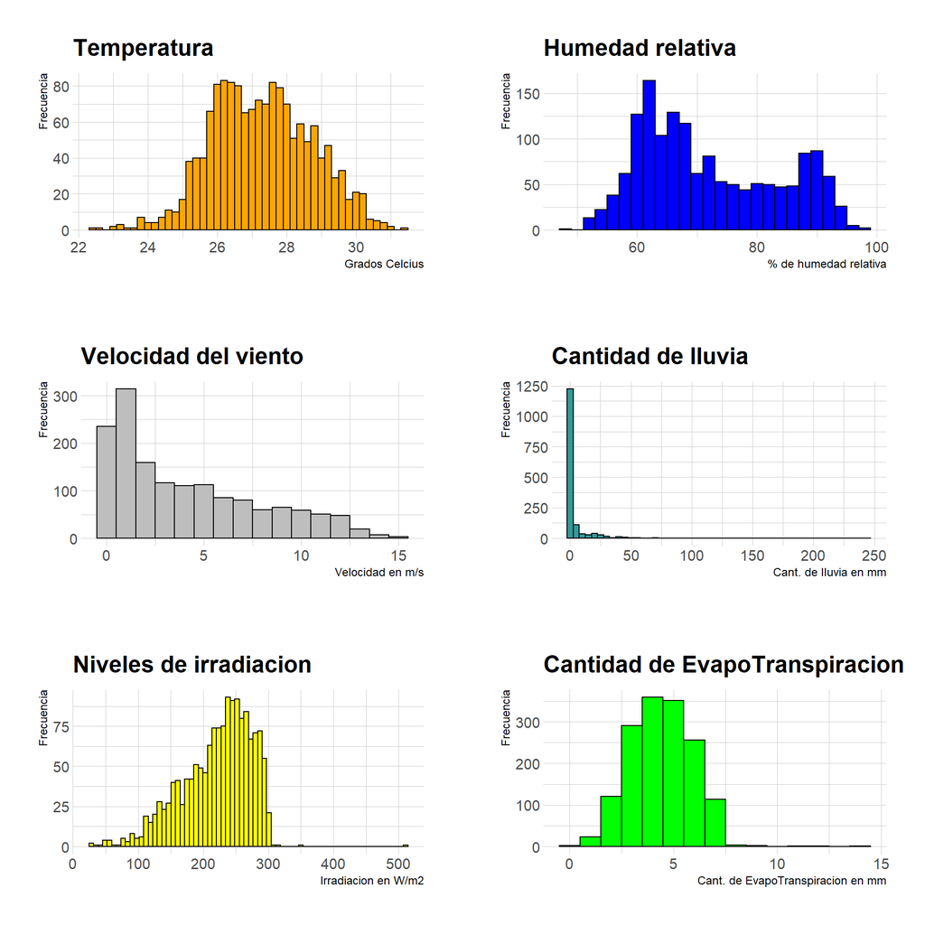

```r
grid.arrange(hist1, hist2, hist3, hist4, hist5, hist6)
```

### Seguidamente mediante los comandos select(), mutate(), group_by() y summarise() se promedia mensualmente cada variable, y la sumatoria de la lluvia y la EvapoTranspiracion, cabe recalcar que estas ultimas dos se encuentran en mm, todo esto se realiza con un data.frame

```r
Temperatura_mensual <-
  datos %>%
  select(Fecha, Temperatura) %>%
  mutate(Fecha = as.Date(Fecha, format = "%d/%m/%Y")) %>%
  group_by(mes = format(Fecha, "%m")) %>%
  summarise(prom_temp = mean(Temperatura))

Humedad_mensual <-
  datos %>%
  select(Fecha, Humedad) %>%
  mutate(Fecha = as.Date(Fecha, format = "%d/%m/%Y")) %>%
  group_by(mes = format(Fecha, "%m")) %>%
  summarise(prom_hum = mean(Humedad))

Vel.Viento_mensual <-
  datos %>%
  select(Fecha, Vel.Viento) %>%
  mutate(Fecha = as.Date(Fecha, format = "%d/%m/%Y")) %>%
  group_by(mes = format(Fecha, "%m")) %>%
  summarise(prom_viento = mean(Vel.Viento))

Irradiacion_mensual <-
  datos %>%
  select(Fecha, Irradiacion) %>%
  mutate(Fecha = as.Date(Fecha, format = "%d/%m/%Y")) %>%
  group_by(mes = format(Fecha, "%m")) %>%
  summarise(prom_irrad = mean(Irradiacion))

Lluvia_mensual <-
  datos %>%
  select(Fecha, Lluvia) %>%
  mutate(Fecha = as.Date(Fecha, format = "%d/%m/%Y")) %>%
  group_by(mes = format(Fecha, "%m")) %>%
  summarise(sum_lluvia = sum(Lluvia))

EvapoTranspiracion_mensual <-
  datos %>%
  select(Fecha, EvapoTranspiracion) %>%
  mutate(Fecha = as.Date(Fecha, format = "%d/%m/%Y")) %>%
  group_by(mes = format(Fecha, "%m")) %>%
  summarise(sum_evapo = sum(EvapoTranspiracion))
```

### Luego de haberse promediado por mes cada variable por medio del data.frame anterior, se crean los gráficos de estos

```r
grafico1 <- ggplot(Temperatura_mensual, aes(x = mes, y = prom_temp, group = 1)) +
  ggtitle('Promedio de temperatura mensual') +
  xlab('Meses') +
  ylab('Grados Celsius') +
  geom_point(colour = "yellow", size = 2) +
  geom_line(colour = "yellow", size  = 1)

grafico2 <- ggplot(Humedad_mensual, aes(x = mes, y = prom_hum, group = 1)) +
  ggtitle('Promedio de porcentaje de humedad mensual') +
  xlab('Meses') +
  ylab('Porcentaje de humedad relativa') +
  geom_point(colour = "#009900", size = 2) +
  geom_line(colour = "#009900", size = 1)

grafico3 <- ggplot(Vel.Viento_mensual, aes(x = mes, y = prom_viento, group = 1)) +
  ggtitle('Promedio de velocidad del viento mensual') +
  xlab('Meses') +
  ylab('Velocidad del viento (m/s)') +
  geom_point(colour = "#ff6600", size = 2) +
  geom_line(colour = "#ff6600", size = 1)

grafico4 <- ggplot(Irradiacion_mensual, aes(x = mes, y = prom_irrad, group = 1)) +
  ggtitle('Niveles de irradiacion mensual') +
  xlab('Meses') +
  ylab('Nivel de irradiacion (w/m2)') +
  geom_point(colour = "purple", size = 2) +
  geom_line(colour = "purple", size = 1)

grafico5 <- ggplot(Lluvia_mensual, aes(x = mes, y = sum_lluvia, group = 1)) +
  ggtitle('Sumatoria mensual de la Lluvia') +
  xlab('Meses') +
  ylab('Cantidad de Lluvia (mm)') +
  geom_point(colour = "#339999", size = 2) +
  geom_line(colour = "#339999", size = 1)

grafico6 <- ggplot(EvapoTranspiracion_mensual, aes(x = mes, y = sum_evapo, group = 1)) +
  ggtitle('Sumatoria mensual de la EvapoTranspiracion') +
  xlab('Meses') +
  ylab('Cantidad de EvapoTranspiracion (mm)') +
  geom_point(colour = "black", size = 2) +
  geom_line(colour = "black", size = 1)
```

### Una vez creados los graficos se unifican en un mismo grafico con el comando grid.arrange

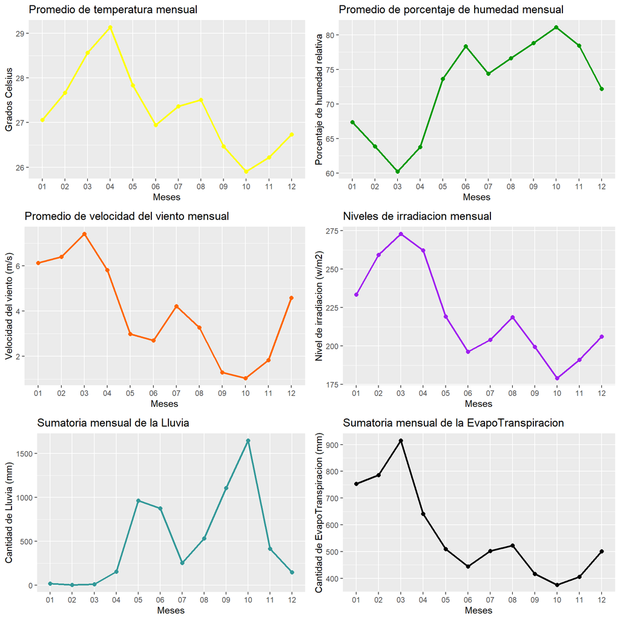

```r
grid.arrange(grafico1, grafico2, grafico3, grafico4, grafico5, grafico6)
```

### Para finalizar se compara la información de variables entre si, mediante una nube de puntos, para esto primero se crea un data.frame nuevo que contenga la información promediada de cada mes de los cuatro años, es decir, el promedio mensual de 51 meses desde enero 2015 hasta marzo 2019

```r
Data_anual <-
  datos %>%
  select(Fecha, Temperatura, Humedad, Vel.Viento, Lluvia, Irradiacion, EvapoTranspiracion) %>%
  mutate(Fecha = as.Date(Fecha, format = "%d/%m/%Y")) %>%
  group_by(meses = format(Fecha, "%m/%Y")) %>%
  summarise(temp_anual = mean(Temperatura),
            hume_anual = mean(Humedad),
            viento_anual = mean(Vel.Viento),
            lluv_anual = mean(Lluvia),
            irrad_anual = mean(Irradiacion),
            evapo_anual = mean(EvapoTranspiracion))
```

### Con este nuevo data.frame se grafican las variables entre si, a cada grafico se le asigna un nombre para poder utilizar el comando grid.arrange

```r
point1 <- ggplot(Data_anual, aes(x = evapo_anual, y = lluv_anual)) +
  geom_point(colour = 'blue') +
  ggtitle('Relación Lluvia/EvapoTranspiración') +
  xlab('EvapoTranspiración') +
  ylab('Lluvia') +
  theme_ipsum(
    grid = "Y, y"
  )

point2 <- ggplot(Data_anual, aes(x = hume_anual, y = temp_anual)) +
  geom_point(colour = '#009900') +
  ggtitle('Relación Humedad/Temperatura') +
  xlab('Humedad') +
  ylab('Temperatura') +
  theme_ipsum(
    grid = "Y, y"
  )

point3 <- ggplot(Data_anual, aes(x = evapo_anual, y = hume_anual)) +
  geom_point(colour = '#cc0066') +
  ggtitle('Relación Humedad/EvapoTranspiración') +
  xlab('EvapoTranspiración') +
  ylab('Humedad') +
  theme_ipsum(
    grid = "Y, y"
  )

point4 <- ggplot(Data_anual, aes(x = temp_anual, y = irrad_anual)) +
  geom_point(colour = '#cc6600') +
  ggtitle('Relación Temperatura/Irradiación') +
  xlab('Temperatura') +
  ylab('Irradiación') +
  theme_ipsum(
    grid = "Y, y"
  )

point5 <- ggplot(Data_anual, aes(x = hume_anual, y = viento_anual)) +
  geom_point(colour = '#00cccc') +
  ggtitle('Relación Humedad/Velocidad del Viento') +
  xlab('Humedad') +
  ylab('Velocidad del Viento') +
  theme_ipsum(
    grid = "Y, y"
  )

point6 <- ggplot(Data_anual, aes(x = hume_anual, y = lluv_anual)) +
  geom_point(colour = '#cc00ff') +
  ggtitle('Relación Humedad/Lluvia') +
  xlab('Humedad') +
  ylab('Lluvia') +
  theme_ipsum(
    grid = "Y, y"
  )
```

### Como ultimo paso se unifican las nubes de puntos con el comando grid.arrange

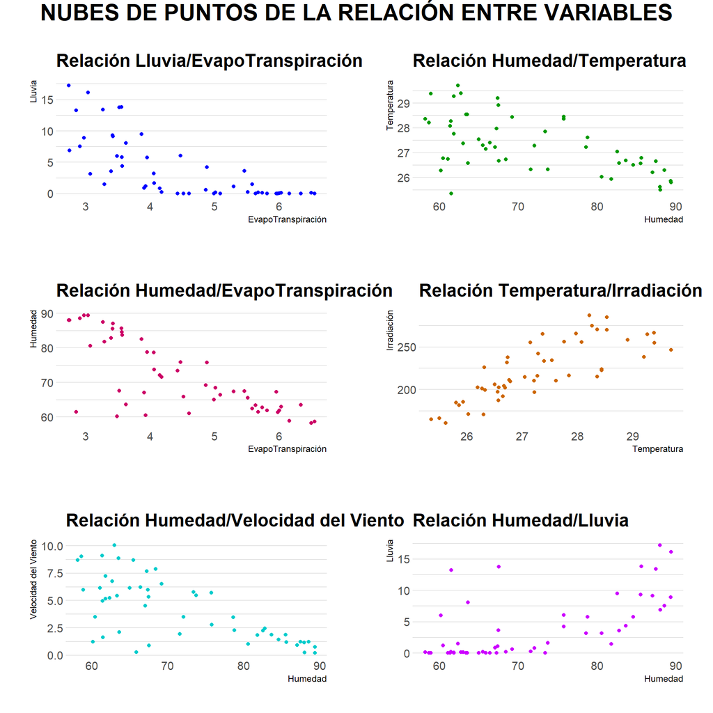

```r
grid.arrange(point1, point2, point3, point4, point5, point6,
             top = textGrob(
               gp = gpar(fontface = 2, fontsize = 23),
               "NUBES DE PUNTOS DE LA RELACIÓN ENTRE VARIABLES"))
```